# Monthly_Sales_Analysis

## **Task #2**

Analyzing Monthly sales of a company.

### 📊Step 1: Import Customized Dataset

We will start by importing a customized dataset in CSV format, containing 12 rows for a yearly/monthly analysis.

⚒️ Tools Utilized

- 🤖ChatGPT (for customizing the dataset)
- 🐍 Python ( for data processing and analysis)
- 🐼 Pandas library (for importing and loading the dataset)
- 📊 Matplotlib library (for data visualization and plotting)

### 🔑Key Concepts

- Data visualization, plot(), xlabel(), ylabel(), title()

```python
import matplotlib.pyplot as plt
import pandas as pd
monthly_sales = pd.read_csv("/content/Monthly_sales_dataset.csv") #paste the file path
monthly_sales
```

|  | Month | Sales($) |
| --- | --- | --- |
| 0 | January | 12000 |
| 1 | February | 15000 |
| 2 | March | 13000 |
| 3 | April | 17000 |
| 4 | May | 16000 |
| 5 | June | 18000 |
| 6 | July | 17500 |
| 7 | August | 19000 |
| 8 | September | 18500 |
| 9 | October | 20000 |
| 10 | November | 19500 |
| 11 | December | 22000 |

### 📈Data Visualization Libraries

For visualizing data, we mainly use:

- Matplotlib (for basic and simple plots)
- Seaborn (for complex plots with availability of beautiful themes and paletes)

We will plot a line chart.

> 💡Line charts are ideal for trend analysis 📈.

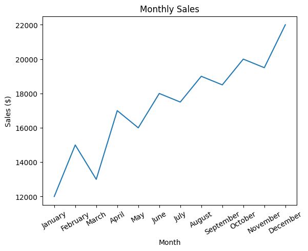

```python
 # Here we use matplotlib
plt.plot(monthly_sales["Month"], monthly_sales["Sales($)"])
plt.title("Monthly Sales")
plt.xlabel("Month")
plt.ylabel("Sales ($)")
plt.xticks(rotation=30) # Rotate x-axis labels by 30 degrees

plt.show()
```

### 🔍Monthly Sales Analysis

We can also further dissect our data by month for deep insights.

> 💡Bar plot would be best to observe changes in monthly sales 📊.

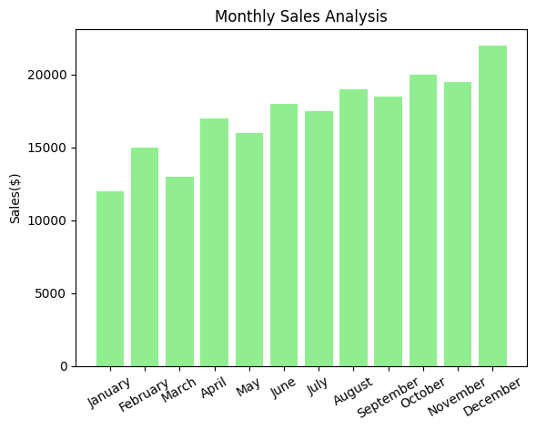

```python
plt.bar(monthly_sales["Month"], monthly_sales["Sales($)"], color='lightgreen')
plt.title("Monthly Sales Analysis")
plt.ylabel("Sales($)")
plt.xticks(rotation=30)
plt.show()
```

### 📝Sales Analysis Summary:

**Analyzing the sales data:**

**🔑 Key Points**

**1. Lowest Sales**

- January (post-holiday dip)

**2. Highest Sales**

- December (peak holiday season)

**3. Mid-year Trend**

- Steady increase with slight dips (possibly due to seasonal fluctuations or marketing/promotion impact)

**4. Overall Trend**

- Upward trend throughout the year
- Growth is consistent with seasonal peaks at the end of the year